# TmCalculator: A Comprehensive Tool for Melting Temperature Calculations

Junhui Li

2025-06-11

# Introduction

The TmCalculator package provides comprehensive options for calculating melting temperatures (Tm) of DNA/RNA sequences. This vignette demonstrates the package’s functionality, including:

- Basic sequence input and Tm calculation with Wallace rule method
- Genomic coordinate input and Tm calculation with nearest neighbor method
- FASTA file input and Tm calculation with nearest neighbor method
- Complementary sequence input and Tm calculation with nearest neighbor method
- DNA genome melting temperature map visualization
- An overview of R shiny application

## Installation

```r
# Install required packages
suppressMessages({
  library(BiocManager)
  BiocManager::install(c("Biostrings", "BSgenome", "BSgenome.Hsapiens.UCSC.hg38"))
})
install.packages("TmCalculator")
pak::pkg_install("Gviz")
pak::pkg_install("JunhuiLi1017/TmCalculator@dev")
```

# Basic Usage

## Simple Sequence Input with Wallace rule method

```r
library(TmCalculator)
library(BSgenome.Hsapiens.UCSC.hg38)
library(GenomicRanges)
library(IRanges)
# Calculate Tm for simple sequences
seqs <- c("ATGCGCGAAAT", "GCTAGCTAGCT")
names(seqs) <- c("chr1:1-11:+:seq1", "chr2:1-11:+:seq2")
result <- tm_calculate(seqs, method = "tm_wallace")
print(result)
```

```
#> $tm
#> GRanges object with 2 ranges and 3 metadata columns:
#>        seqnames    ranges strand |    sequence  complement        Tm
#>           <Rle> <IRanges>  <Rle> | <character> <character> <numeric>
#>   seq1     chr1      1-11      + | ATGCGCGAAAT TACGCGCTTTA        32
#>   seq2     chr2      1-11      + | GCTAGCTAGCT CGATCGATCGA        34
#>   -------
#>   seqinfo: 2 sequences from an unspecified genome; no seqlengths
```

## Genomic Coordinate Input with nearest neighbor method

### In this example, we calculate the melting temperature of the sequences in the hg38 genome with nearest neighbor method. The coordinates should be in the format of “chr:start-end:+:genome_name:seq_name”

```r
# Example with genomic coordinates
library("BSgenome.Hsapiens.UCSC.hg38")
coords <- c(
  "chr1:1898000-1898050:+:BSgenome.Hsapiens.UCSC.hg38:seq1",
  "chr2:2563000-2563050:-:BSgenome.Hsapiens.UCSC.hg38:seq2"
)
result <- tm_calculate(coords)
result
```

```
#> $tm
#> GRanges object with 2 ranges and 4 metadata columns:
#>        seqnames          ranges strand |               sequence
#>           <Rle>       <IRanges>  <Rle> |            <character>
#>   seq1     chr1 1898000-1898050      + | AAAAACCCCACAAACCTCCC..
#>   seq2     chr2 2563000-2563050      - | GCAGCCTTTTGAGGAGCCCA..
#>                        genome             complement        Tm
#>                   <character>            <character> <numeric>
#>   seq1 BSgenome.Hsapiens.UC.. TTTTTGGGGTGTTTGGAGGG..   66.2586
#>   seq2 BSgenome.Hsapiens.UC.. CGTCGGAAAACTCCTCGGGT..   78.8140
#>   -------
#>   seqinfo: 2 sequences from an unspecified genome; no seqlengths
```

### The options of the nearest neighbor method are:

```r
result$tm$Options
```

```
#> $Ambiguous
#> [1] FALSE
#>
#> $Shift
#> [1] 0
#>
#> $`Thermodynamic NN values`
#> [1] "DNA_NN_SantaLucia_2004: SantaLucia J (2004) <doi:10.1146/annurev.biophys.32.110601.141800>"
#>
#> $`Thermodynamic values for terminal mismatches`
#> [1] "DNA_TMM_Bommarito_2000: Bommarito S (2000)  <doi:10.1093/nar/28.9.1929>"
#>
#> $`Thermodynamic values for internal mismatches`
#> [1] "DNA_IMM_Peyret_1999: Peyret N (1999) <doi:10.1021/bi9825091> & Allawi H T (1997) <doi:10.1021/bi962590c> & Santalucia N (2005) <doi:10.1093/nar/gki918>"
#>
#> $`Thermodynamic values for dangling ends`
#> [1] "DNA_DE_Bommarito_2000: Bommarito S (2000) <doi:10.1093/nar/28.9.1929>"
#>
#> $`Concentration of the higher concentrated strand`
#> [1] 25
#>
#> $`Concentration of the lower concentrated strand`
#> [1] 25
#>
#> $`Sequence self-complementary`
#> [1] FALSE
#>
#> $Na
#> [1] 50
#>
#> $K
#> [1] 0
#>
#> $Tris
#> [1] 0
#>
#> $Mg
#> [1] 0
#>
#> $dNTPs
#> [1] 0
#>
#> $`Salt correction method`
#> [1] "Schildkraut2010"
#>
#> $`Percent of DMSO`
#> [1] 0
#>
#> $`Formamide concentration`
#> [1] 0
#>
#> $`Coeffecient of Tm decreases per percent DMSO`
#> [1] 0.75
#>
#> $`Method for formamide concentration`
#> [1] "percent"
#>
#> $`Coefficient of Tm decrease per percent formamide`
#> [1] 0.65
```

## FASTA File Processing

### In this example, we calculate the melting temperature of the sequences in the fasta file with nearest neighbor method.

```r
# Process sequences from a FASTA file
fasta_file <- system.file("extdata", "example1.fasta", package = "TmCalculator")
result_fa <- tm_calculate(fasta_file)
result_fa
```

```
#> $tm
#> GRanges object with 3 ranges and 3 metadata columns:
#>        seqnames            ranges strand |               sequence
#>           <Rle>         <IRanges>  <Rle> |            <character>
#>   seq1    chr22 13209021-13209099      + | ATGCGATCGATCGATCGATC..
#>   seq2     chr1              1-76      * | GCAACGACGACGACGACGAC..
#>      3    chr14       13200-13222      * | GCGATCGATCGATCGATCGA..
#>                    complement        Tm
#>                   <character> <numeric>
#>   seq1 TACGCTAGCTAGCTAGCTAG..   69.1147
#>   seq2 CGTTGCTGCTGCTGCTGCTG..   71.1160
#>      3 CGCTAGCTAGCTAGCTAGCT..   50.7169
#>   -------
#>   seqinfo: 3 sequences from an unspecified genome; no seqlengths
```

## Complementary Sequence with a mismatch

### In this example, we calculate the melting temperature of the complementary sequences with nearest neighbor method. there is a mismatch between the two sequences.

GCTAGCCGA[C]AATGGGCAGATAGTAGAAA CGATCGGCT[A]TTACCCGTCTATCATCTTT

```r
# Example with provided complementary sequences
seqs <- c("GCTAGCCGACAATGGGCAGATAGTAGAAA")
comp_seqs <- c("CGATCGGCTATTACCCGTCTATCATCTTT")
result <- tm_calculate(input_seq=seqs,complement_seq=comp_seqs, method="tm_nn")
result
```

```
#> $tm
#> GRanges object with 1 range and 3 metadata columns:
#>     seqnames    ranges strand |               sequence             complement
#>        <Rle> <IRanges>  <Rle> |            <character>            <character>
#>   1     chr1      1-29      * | GCTAGCCGACAATGGGCAGA.. CGATCGGCTATTACCCGTCT..
#>            Tm
#>     <numeric>
#>   1   54.2609
#>   -------
#>   seqinfo: 1 sequence from an unspecified genome; no seqlengths
```

## Complementary Sequence with a dangling end and a mismatch

### In this example, we calculate the melting temperature of the complementary sequences with nearest neighbor method. there is a dangling end between the two sequences.

GCTAGCCGA[C]AATGGGCAGATAGTAGAAA GATCGGCT[A]TTACCCGTCTATCATCTTT

```r
seqs <- c("GCTAGCCGACAATGGGCAGATAGTAGAAA")
comp_seqs <- c("GATCGGCTATTACCCGTCTATCATCTTT")
result <- tm_calculate(input_seq=seqs,
                       complement_seq=comp_seqs,
                       method="tm_nn",
                       shift=-1)
result
```

```
#> $tm
#> GRanges object with 1 range and 3 metadata columns:
#>     seqnames    ranges strand |               sequence             complement
#>        <Rle> <IRanges>  <Rle> |            <character>            <character>
#>   1     chr1      1-29      * | GCTAGCCGACAATGGGCAGA.. GATCGGCTATTACCCGTCTA..
#>            Tm
#>     <numeric>
#>   1   52.3654
#>   -------
#>   seqinfo: 1 sequence from an unspecified genome; no seqlengths
```

# Visualization of Tm values

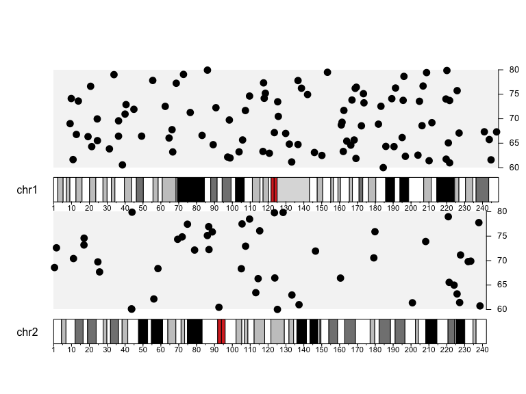

```r
# Generate sample data with 150 sequences
set.seed(123)

# Generate 100 sequences for chr1
chr1_starts <- sort(sample(1:249250621, 100))  # chr1 length in hg19
chr1_lengths <- sample(50:200, 100, replace=TRUE)
chr1_ends <- chr1_starts + chr1_lengths
chr1_tms <- runif(100, min=60, max=80)

# Generate 50 sequences for chr2
chr2_starts <- sort(sample(1:243199373, 50))   # chr2 length in hg19
chr2_lengths <- sample(50:200, 50, replace=TRUE)
chr2_ends <- chr2_starts + chr2_lengths
chr2_tms <- runif(50, min=60, max=80)

# Create GRanges object
tm_results <- GRanges(
  seqnames = Rle(c(rep("chr1", 100), rep("chr2", 50))),
  ranges = IRanges(
    start = c(chr1_starts, chr2_starts),
    end = c(chr1_ends, chr2_ends)
  ),
  strand = Rle(sample(c("+", "-"), 150, replace=TRUE)),
  Tm = c(chr1_tms, chr2_tms)
)
genome(seqinfo(tm_results)) <- "hg38"

# Example usage by plot_tm_karyotype
plot_tm_karyotype(tm_results, genome_assembly = "hg38")
```

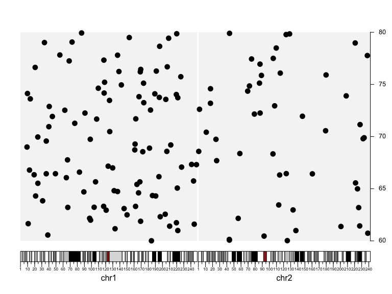

```r
# Example usage by plot_tm_genome_tracks with custom settings (plot_type=4)
plot_tm_karyotype(tm_results,
                  genome_assembly = "hg38",
                  plot_type = 4,
                  xaxis_cex = 0.5
                  )
```

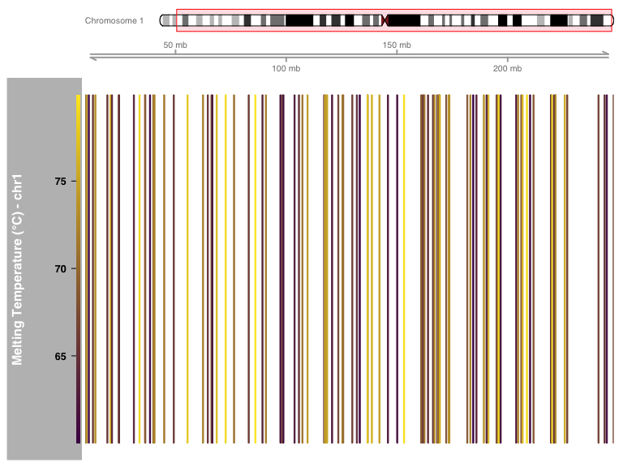

```r
# Example usage by plot_tm_genome_tracks with default settings (plot_type=1)
plot_tm_genome_tracks(tm_results, chromosome_to_plot = "chr1", genome_assembly = "hg38")
```

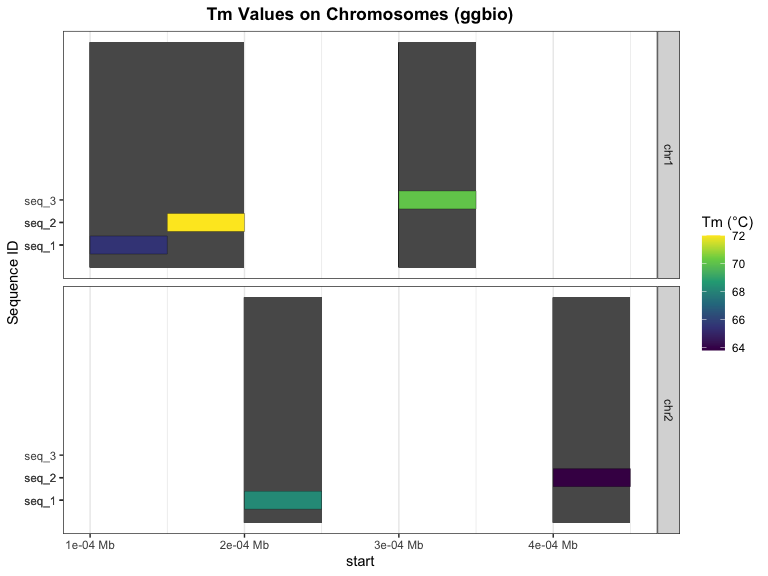

```r
# Create example GRanges object
gr_tm <- GenomicRanges::GRanges(
  seqnames = c("chr1", "chr2", "chr1", "chr2", "chr1"),
  ranges = IRanges::IRanges(
    start = c(100, 200, 300, 400, 150),
    end = c(150, 250, 350, 450, 200)
  ),
  Tm = c(65.5, 68.2, 70.1, 63.8, 72.0)
)

# Plot with ideograms
plot_tm_heatmap(gr_tm, genome_assembly = "hg19", plot_type = "karyogram")
```

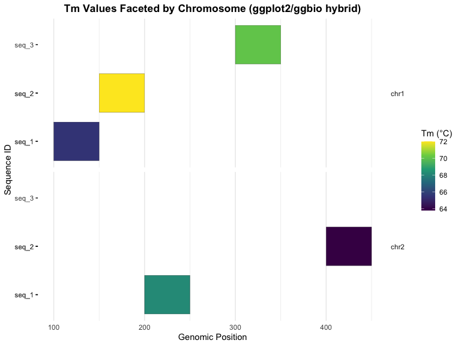

```r
# Faceted plot by chromosome
plot_tm_heatmap(gr_tm, genome_assembly = "hg19", plot_type = "faceted")
```

## launch the shiny application

```r
TmCalculatorShinyApp()
```

# Conclusion

The TmCalculator package provides a comprehensive suite of tools for calculating and analyzing melting temperatures of DNA/RNA sequences. The visualization tools help in understanding the genomic context and comparing Tm values across different sequences.

For more information, please refer to the package documentation and examples.